```python
__author__ = "Yuqiao(Echo) Zhong"
__email__ = "yuqiao.zhong@simon.rochester.edu"
__website__ = "https://www.linkedin.com/in/yuqiaoechozhong/"
```

# Part 1 - Introduction

Lending Club connects people who need money (borrowers) with people who have money (investors). Here we will use Python with some packages like Pandas, Matplotlib and seaborn to analyze a dataset that was collected on lending.com over 2007-2010. The dataset contains data on more than 9000 borrowers and borrowers' features like income, FICO, interest rate, etc. We will analyze this data to get insights on the main difference between fully paid borrowers and not fully paid borrowers. These insights might also be used by people in landing.com to better predict whether the borrower will pay in full or not.

## Goals of the analysis

**We want to answer questions like:**

- What are the main differences between not fully paid and fully paid borrowers?
- What are the main purposes of the borrowers that use lending.com? How does interest rate differ between each purpose? How do purposes correlate with other features?
- Do fully paid borrowers tend to have lower revolving balance than not fully paid borrwers? What about revolving utilization rate?
- How do income and FICO impact borrower's interest rate?
- Given the same FICO socre, do fully paid borrowers tend to have lower interest rate? What about different credit policies?
- Do fully paid borrowers have less public record and tend to pay back on time? How will these behaviors impact interest rate?

**First let's load the necessary packages and data.**

```python
import pandas as pd
import numpy as np
import matplotlib.pyplot as plt
import seaborn as sns
%matplotlib inline
```

```python
loans = pd.read_csv('loan_data.csv')
loans.head()
```

|  | credit.policy | purpose | int.rate | installment | log.annual.inc | dti | fico | days.with.cr.line | revol.bal | revol.util | inq.last.6mths | delinq.2yrs | pub.rec | not.fully.paid |
| --- | --- | --- | --- | --- | --- | --- | --- | --- | --- | --- | --- | --- | --- | --- |
| 0 | 1 | debt_consolidation | 0.1189 | 829.10 | 11.350407 | 19.48 | 737 | 5639.958333 | 28854 | 52.1 | 0 | 0 | 0 | 0 |
| 1 | 1 | credit_card | 0.1071 | 228.22 | 11.082143 | 14.29 | 707 | 2760.000000 | 33623 | 76.7 | 0 | 0 | 0 | 0 |
| 2 | 1 | debt_consolidation | 0.1357 | 366.86 | 10.373491 | 11.63 | 682 | 4710.000000 | 3511 | 25.6 | 1 | 0 | 0 | 0 |
| 3 | 1 | debt_consolidation | 0.1008 | 162.34 | 11.350407 | 8.10 | 712 | 2699.958333 | 33667 | 73.2 | 1 | 0 | 0 | 0 |
| 4 | 1 | credit_card | 0.1426 | 102.92 | 11.299732 | 14.97 | 667 | 4066.000000 | 4740 | 39.5 | 0 | 1 | 0 | 0 |

Here are what the columns represent:

- credit.policy: 1 if the customer meets the credit underwriting criteria of LendingClub.com, and 0 otherwise.
- purpose: The purpose of the loan (takes values "credit_card", "debt_consolidation", "educational", "major_purchase", "small_business", and "all_other").
- int.rate: The interest rate of the loan, as a proportion (a rate of 11% would be stored as 0.11). Borrowers judged by LendingClub.com to be more risky are assigned higher interest rates.
- installment: The monthly installments owed by the borrower if the loan is funded.
- log.annual.inc: The natural log of the self-reported annual income of the borrower.
- dti: The debt-to-income ratio of the borrower (amount of debt divided by annual income).
- fico: The FICO credit score of the borrower.
- days.with.cr.line: The number of days the borrower has had a credit line.
- revol.bal: The borrower's revolving balance (amount unpaid at the end of the credit card billing cycle).
- revol.util: The borrower's revolving line utilization rate (the amount of the credit line used relative to total credit available).
- inq.last.6mths: The borrower's number of inquiries by creditors in the last 6 months.
- delinq.2yrs: The number of times the borrower had been 30+ days past due on a payment in the past 2 years.
- pub.rec: The borrower's number of derogatory public records (bankruptcy filings, tax liens, or judgments).

# Part 2 - Dataset Overview

**First, let's take a look at our target column: the ratio of fully paid and not fully paid borrowers.**

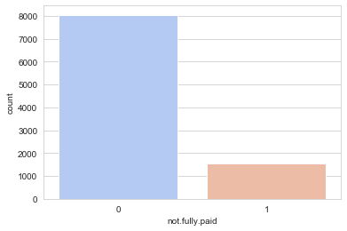

```python
sns.countplot(x='not.fully.paid', data=loans,palette = 'coolwarm')
```

The dataset has a lot more borrowers that paid in full. This dataset is very unbalanced. Note this might be challenging if we want to build a model off from it.

**Now I want to take a look at the whole dataset to get a general sense of it**

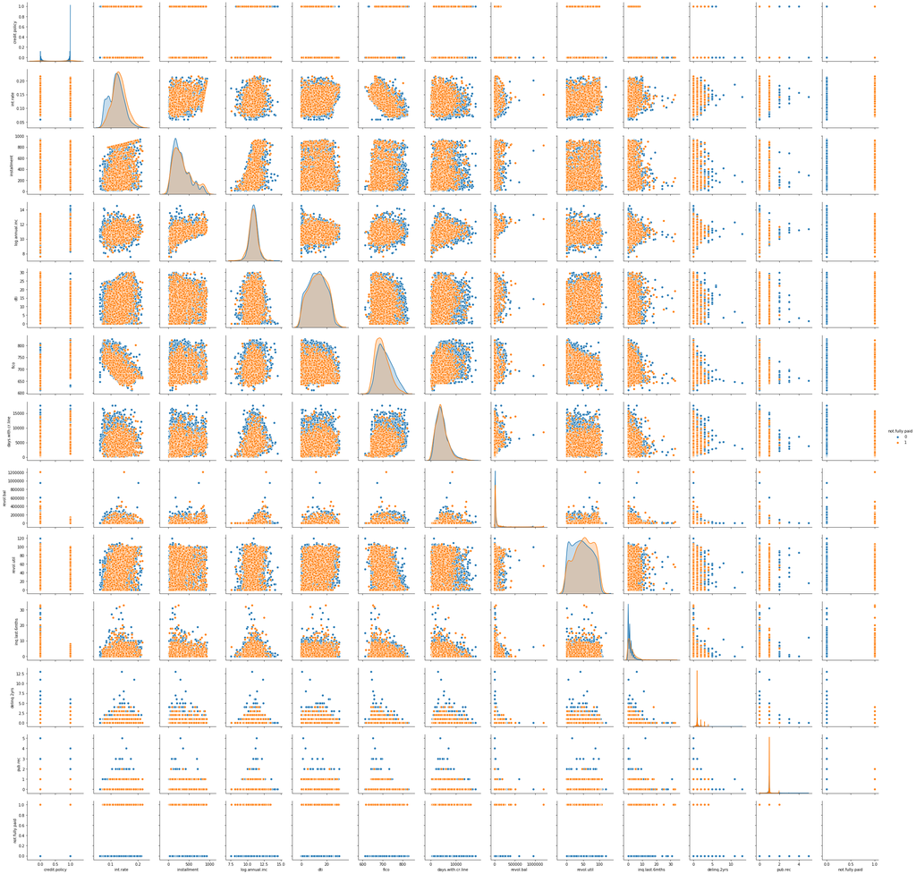

```python
sns.pairplot(data=loans,hue='not.fully.paid')
```

Shown in the graph, the differences between the two groups are not that significant. Let's further explore some of the more obvious correlation pairs in detail.

## Correlation in detail

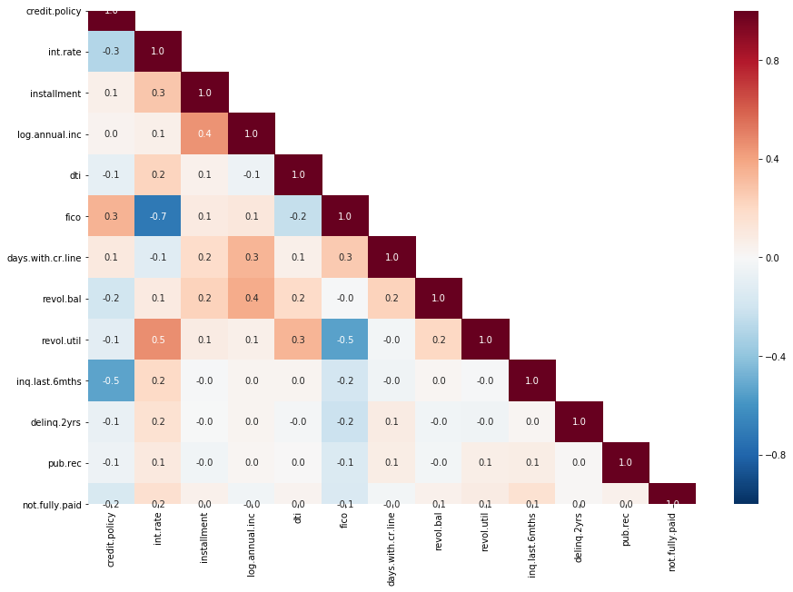

```python
# Create correlation matrix
corr_mat = loans.corr()

# Create mask
mask = np.zeros_like(corr_mat, dtype=np.bool)
mask[np.triu_indices_from(mask, k=1)] = True

# Plot heatmap
plt.figure(figsize=(15, 10))
sns.heatmap(corr_mat, annot=True, fmt='.1f',
            cmap='RdBu_r', vmin=-1, vmax=1,
            mask=mask)
```

# Part 3 - Description on categorical variables (purposes)

```python
loans.describe(include=['O'])
```

|  | purpose |
| --- | --- |
| count | 9578 |
| unique | 7 |
| top | debt_consolidation |
| freq | 3957 |

There are 7 main purposes and Debt_solidation seems to be the most popular reason for borrowers.

**Let's see how purposes differ between the fully paid and not fully paid borrowers**

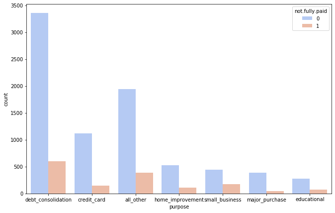

```python
plt.figure(figsize=(11,7))
sns.countplot(x='purpose',hue='not.fully.paid',data=loans,palette='coolwarm')
```

Note that debt consolidation and credit card are popular among both kinds of borrowers.

**Will interest rate and FICO differ between different purposes?**

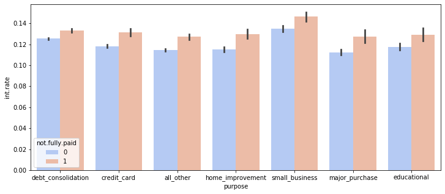

```python
plt.figure(figsize=(12,5))
sns.barplot(y='int.rate',x='purpose',hue='not.fully.paid',data=loans,palette='coolwarm')
```

Overall, interest rate for not fully paid borrowers is higher than fully paid borrowers.

Also, interest rate for small business purpose is higher than other purposes for both kinds of borrowers, at about 14%.

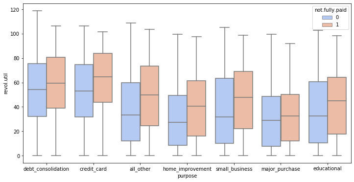

```python
plt.figure(figsize=(12,6))
sns.boxplot(x='purpose',y='revol.util',hue='not.fully.paid',data=loans,palette='coolwarm')
```

Majority of the borrower's revolving line utilization rate is generally higher for the credit card purpose and debt conlidation purpose. Borrowers that paid back fully tend to have lower revolving line utilization rate.

# Part 4 - Description on numerical variables

```python
loans.describe()
```

|  | credit.policy | int.rate | installment | log.annual.inc | dti | fico | days.with.cr.line | revol.bal | revol.util | inq.last.6mths | delinq.2yrs | pub.rec | not.fully.paid |
| --- | --- | --- | --- | --- | --- | --- | --- | --- | --- | --- | --- | --- | --- |
| count | 9578.000000 | 9578.000000 | 9578.000000 | 9578.000000 | 9578.000000 | 9578.000000 | 9578.000000 | 9.578000e+03 | 9578.000000 | 9578.000000 | 9578.000000 | 9578.000000 | 9578.000000 |
| mean | 0.804970 | 0.122640 | 319.089413 | 10.932117 | 12.606679 | 710.846314 | 4560.767197 | 1.691396e+04 | 46.799236 | 1.577469 | 0.163708 | 0.062122 | 0.160054 |
| std | 0.396245 | 0.026847 | 207.071301 | 0.614813 | 6.883970 | 37.970537 | 2496.930377 | 3.375619e+04 | 29.014417 | 2.200245 | 0.546215 | 0.262126 | 0.366676 |
| min | 0.000000 | 0.060000 | 15.670000 | 7.547502 | 0.000000 | 612.000000 | 178.958333 | 0.000000e+00 | 0.000000 | 0.000000 | 0.000000 | 0.000000 | 0.000000 |
| 25% | 1.000000 | 0.103900 | 163.770000 | 10.558414 | 7.212500 | 682.000000 | 2820.000000 | 3.187000e+03 | 22.600000 | 0.000000 | 0.000000 | 0.000000 | 0.000000 |
| 50% | 1.000000 | 0.122100 | 268.950000 | 10.928884 | 12.665000 | 707.000000 | 4139.958333 | 8.596000e+03 | 46.300000 | 1.000000 | 0.000000 | 0.000000 | 0.000000 |
| 75% | 1.000000 | 0.140700 | 432.762500 | 11.291293 | 17.950000 | 737.000000 | 5730.000000 | 1.824950e+04 | 70.900000 | 2.000000 | 0.000000 | 0.000000 | 0.000000 |
| max | 1.000000 | 0.216400 | 940.140000 | 14.528354 | 29.960000 | 827.000000 | 17639.958330 | 1.207359e+06 | 119.000000 | 33.000000 | 13.000000 | 5.000000 | 1.000000 |

From the table above, we see that the mean of revolving balance is 16914, but the median is only 8596, which means half of the borrowers have revolving balance below this number, and half have balance larger than this number.

**Let's take a closer look**

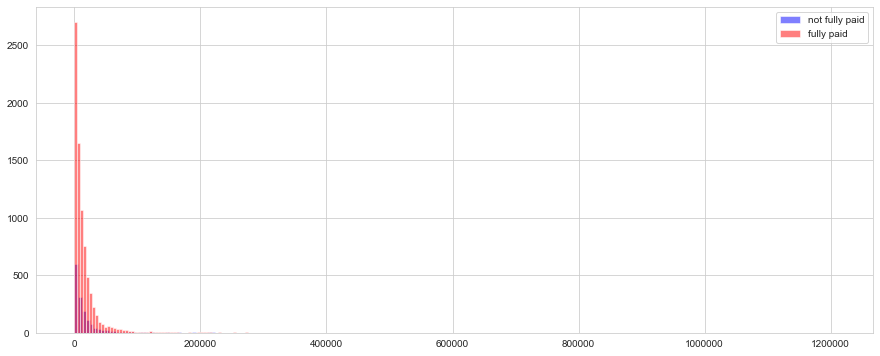

```python
plt.figure(figsize=(15,6))
loans[loans['not.fully.paid']==1]['revol.bal'].hist(alpha=0.5,color='blue',bins=200,label='not fully paid')
loans[loans['not.fully.paid']==0]['revol.bal'].hist(alpha=0.5,color='red',bins=200,label='fully paid')
plt.legend()
```

The distribution between two kinds of borrowers are not that different.

And we see that the majority of borrowers have rovolving balance of 50k or less.

**Let's see the exact percentage of revolving balance that is more than 50k.**

```python
loans[loans['revol.bal'] > 50000]['dti'].count() / loans['revol.bal'].count() * 100
```

```
6.30611818751305
```

**What about the percentage for each kind of borrower?**

```python
no_pay_bal_per = loans[loans['not.fully.paid']==1][loans['revol.bal'] > 50000]['dti'].count() / loans[loans['not.fully.paid']==1].count() * 100
yes_pay_bal_per = loans[loans['not.fully.paid']==0][loans['revol.bal'] > 50000]['dti'].count() / loans[loans['not.fully.paid']==0].count() * 100
print('borrowers that did not pay full: ',no_pay_bal_per.iloc[1])
print('borrowers that paid full: ',yes_pay_bal_per.iloc[1])
```

```
borrowers that did not pay full:  8.349641226353555
borrowers that paid full:  5.9167184586699815
```

**Now that we know a little more about borrowers' revolving balance difference, let's take a look at the distribution of income level.**

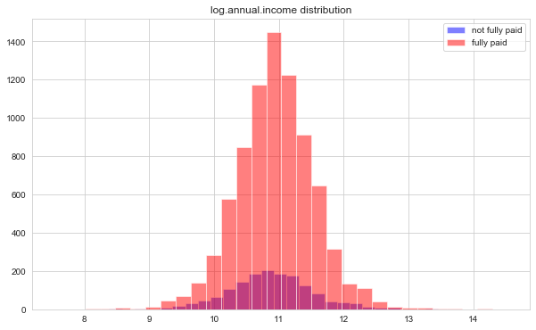

```python
plt.figure(figsize=(10,6))
loans[loans['not.fully.paid']==1]['log.annual.inc'].hist(alpha=0.5,color='blue',
                                              bins=30,label='not fully paid')
loans[loans['not.fully.paid']==0]['log.annual.inc'].hist(alpha=0.5,color='red',
                                              bins=30,label='fully paid')
plt.legend()
plt.title("log.annual.income distribution")
```

Income does not differ by much among both kinds of borrowers. They are all normally distributed around 11.

**Annual income and installment also show some interesting correlation in the pairplot, let's take a closer look.**

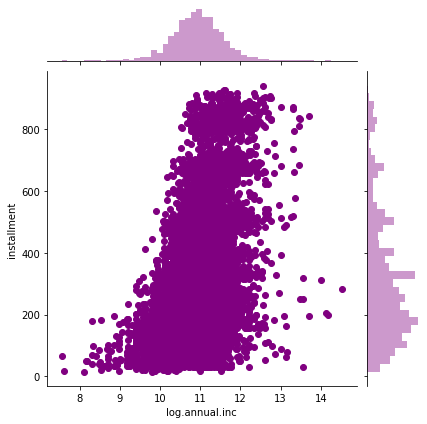

```python
sns.jointplot(x='log.annual.inc',y='installment',data=loans,color='purple')
```

**Interesting finding. But still, not much a difference in income between two groups. What about FICO score? Let's first look at the distribution.**

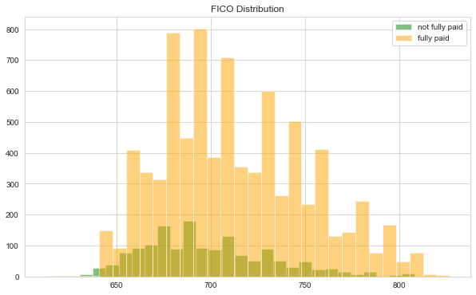

```python
sns.set_style('whitegrid')
plt.figure(figsize=(10,6))
loans[loans['not.fully.paid']==1]['fico'].hist(alpha=0.5,color='green',
                                              bins=30,label='not fully paid')
loans[loans['not.fully.paid']==0]['fico'].hist(alpha=0.5,color='orange',
                                              bins=30,label='fully paid')
plt.legend()
plt.title('FICO Distribution')
```

The score between both borrowers does not differ much. They both have most FICO score at about 675~700.

**I will focus on interest rate because we can see this as an metric to measure how trustworthy the investors think of borrowers.**

**Although there is not much difference between the two groups, from the pairplot we see a clear relationship between FICO and interest rate. Now I want to check whether interest rate different between the two kinds of borrowers given the same fico score.**

**Also I will look at how it differs between people who have met and have not met the credit underwriting criteria.**

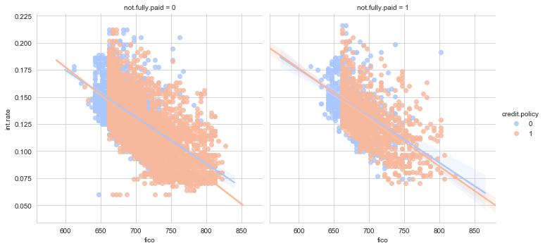

```python
plt.figure(figsize=(11,7))
sns.lmplot(y='int.rate',x='fico',data=loans,hue='credit.policy',
           col='not.fully.paid',palette='coolwarm')
```

For not fully paid borrowers, with the fico score over 650, the one that has met credit policy is more likely to get a lower interest rate. For fully paid people, metting the credit policy or not doesn't make a significant difference on interest rate.

**Finally, I want to check how does public record, and the number of times the borrower had 30+ days past due on a payment in the past 2 years differ between two groups**

**Let's first look at public record**

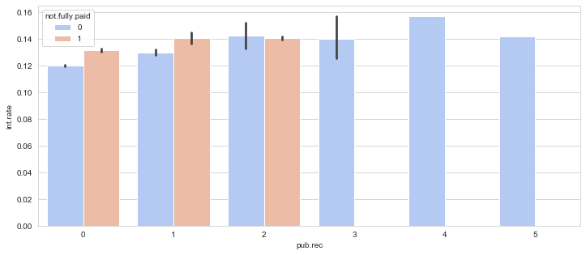

```python
plt.figure(figsize=(12,5))
sns.barplot(y='int.rate',x='pub.rec',hue='not.fully.paid',data=loans,palette='coolwarm')
```

Surprisingly, only fully paid borrowers have over 3 public record. And interest rate goes higher when public record increases. Let's check who are these fully paid borrowers with more than 2 public records.

```python
loans[loans['pub.rec']>2]
```

|  | credit.policy | purpose | int.rate | installment | log.annual.inc | dti | fico | days.with.cr.line | revol.bal | revol.util | inq.last.6mths | delinq.2yrs | pub.rec | not.fully.paid |
| --- | --- | --- | --- | --- | --- | --- | --- | --- | --- | --- | --- | --- | --- | --- |
| 3461 | 1 | credit_card | 0.1316 | 81.05 | 11.184421 | 1.05 | 697 | 3630.000000 | 1229 | 30.0 | 1 | 0 | 3 | 0 |
| 6575 | 1 | home_improvement | 0.1183 | 82.84 | 12.122691 | 8.45 | 692 | 5130.000000 | 399 | 39.9 | 0 | 1 | 3 | 0 |
| 7276 | 1 | major_purchase | 0.1570 | 350.11 | 11.196844 | 3.29 | 662 | 6960.000000 | 4322 | 86.4 | 0 | 0 | 4 | 0 |
| 7626 | 1 | all_other | 0.1422 | 144.00 | 10.878047 | 16.69 | 667 | 4710.000000 | 5804 | 50.9 | 0 | 1 | 3 | 0 |
| 7960 | 0 | credit_card | 0.1343 | 169.51 | 11.492723 | 12.53 | 647 | 2849.958333 | 9568 | 97.1 | 1 | 0 | 3 | 0 |
| 8291 | 0 | debt_consolidation | 0.1734 | 687.79 | 11.242559 | 12.74 | 652 | 6583.000000 | 20767 | 81.1 | 0 | 0 | 3 | 0 |
| 8324 | 0 | credit_card | 0.1418 | 287.83 | 11.379394 | 1.49 | 652 | 3779.041667 | 2885 | 15.8 | 12 | 0 | 5 | 0 |

- All of these fully paid borrowers that have more than 2 public records have lower-than-average fico score.
- Among the seven fully paid borrowers,the lowest interest rate is granted to the borrower that has a purpose of home improvement, and have less than 400 revolving balance. Also, revolving utilization rate is low at 40%. Income level is also higher than average.
- The highest interest rate is granted to the borrower that has a purpose of debt consolidation, has the highest revolving balance and high revolving utilization rate at 81.1%

**Very interesting findings! Finally let's look at how interest rate differ between the number of times the borrower had 30+ days past due on a payment in the past 2 years**

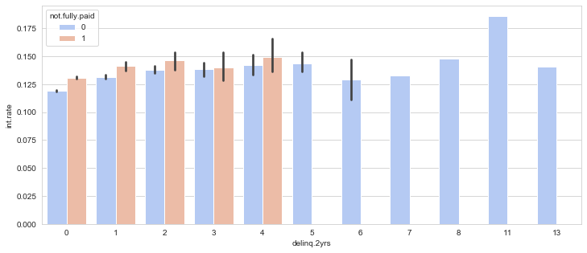

```python
plt.figure(figsize=(12,5))
sns.barplot(y='int.rate',x='delinq.2yrs',hue='not.fully.paid',data=loans,palette='coolwarm')
```

Similar as before, only fully paid borrowers have past due payment for more than 4 times in the past two years. Let's look at these borrowers' characteristics.

```python
loans[loans['delinq.2yrs']>4]
```

|  | credit.policy | purpose | int.rate | installment | log.annual.inc | dti | fico | days.with.cr.line | revol.bal | revol.util | inq.last.6mths | delinq.2yrs | pub.rec | not.fully.paid |
| --- | --- | --- | --- | --- | --- | --- | --- | --- | --- | --- | --- | --- | --- | --- |
| 689 | 1 | debt_consolidation | 0.1324 | 405.72 | 10.878047 | 17.82 | 667 | 7349.000000 | 18593 | 35.0 | 0 | 5 | 1 | 0 |
| 1525 | 1 | all_other | 0.1114 | 196.84 | 11.082143 | 22.41 | 697 | 7350.041667 | 2611 | 7.8 | 0 | 6 | 0 | 0 |
| 5699 | 1 | credit_card | 0.1392 | 546.20 | 11.397515 | 16.51 | 692 | 5790.000000 | 10852 | 60.9 | 0 | 5 | 0 | 0 |
| 6055 | 1 | debt_consolidation | 0.1426 | 205.84 | 11.219467 | 14.05 | 667 | 9240.041667 | 3407 | 48.7 | 2 | 5 | 0 | 0 |
| 7789 | 0 | debt_consolidation | 0.1407 | 171.05 | 10.714418 | 0.53 | 642 | 2846.000000 | 123 | 41.0 | 6 | 13 | 0 | 0 |
| 7871 | 0 | debt_consolidation | 0.1343 | 81.37 | 9.903488 | 11.64 | 652 | 2819.958333 | 233 | 15.1 | 0 | 5 | 0 | 0 |
| 7952 | 0 | debt_consolidation | 0.1470 | 324.48 | 11.170435 | 21.58 | 657 | 2984.000000 | 1992 | 18.3 | 3 | 6 | 0 | 0 |
| 8118 | 0 | debt_consolidation | 0.1330 | 169.20 | 10.341742 | 16.88 | 657 | 5129.000000 | 2229 | 51.8 | 1 | 7 | 0 | 0 |
| 8234 | 0 | debt_consolidation | 0.1482 | 414.93 | 11.396392 | 3.49 | 652 | 5190.000000 | 8016 | 61.7 | 11 | 8 | 0 | 0 |
| 8536 | 0 | all_other | 0.1640 | 353.55 | 12.388394 | 12.37 | 652 | 5850.958333 | 188 | 37.6 | 1 | 5 | 0 | 0 |
| 8548 | 0 | all_other | 0.1861 | 291.68 | 12.301383 | 6.87 | 647 | 4049.958333 | 378 | 5.0 | 0 | 11 | 1 | 0 |
| 8881 | 0 | all_other | 0.1505 | 277.53 | 10.898589 | 14.91 | 667 | 6122.041667 | 26814 | 57.7 | 5 | 5 | 0 | 0 |